# Lab4_R4L

### Baiyu Chen

The dense and sparse of the point can reflect the educated level between two group of people.The plot showed that more people who never smoke had took higher level education rather than people who smoke, for people who never smoke have more dense point on 4 and 5 rather than people who smoke. Furthermore, most of smoker had took lower level education rather that higher level education, we can see there are denser point in 1 and 2 rather than others level. About what I built the plot, I use the jitter function to make this plot, jitter function can easily show us the density of the variable. Furthermore,I change the color of the poings. Also, I add my personal label to each facet and the plot instead of the default label.

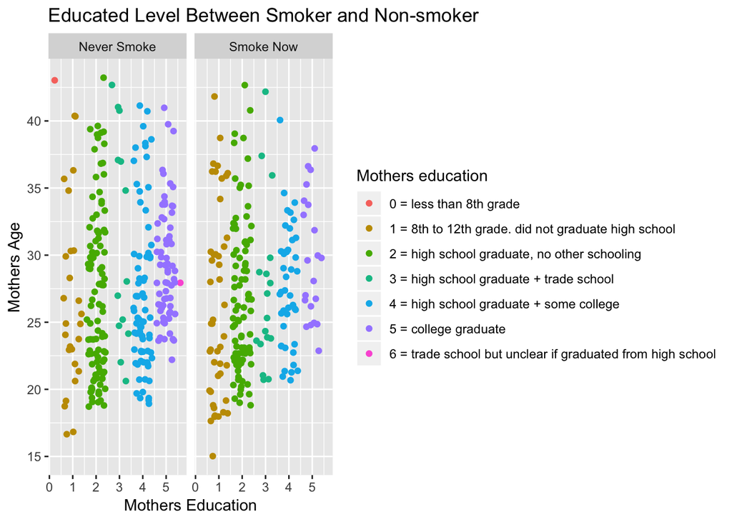

```r
require(ggplot2)
library(dplyr)

babies <-na.omit(babies)

babies <- babies %>%
  mutate(med2 = ifelse(med==7 , 6, med))

ggplot(data = babies)+
  geom_jitter(mapping = aes(x=med2, y=mage, color=as.factor(med2)))+
  facet_wrap(~smoke,labeller=labeller(smoke = c('0' = 'Never Smoke', '1' = 'Smoke Now')))+
   scale_color_discrete(name = 'Mothers education',                                     labels = c('0 = less than 8th grade', '1 = 8th to 12th grade. did not graduate high school', '2 = high school graduate, no other schooling', '3 = high school graduate + trade school', '4 = high school graduate + some college', '5 = college graduate', '6 = trade school but unclear if graduated from high school'))+
  scale_x_continuous(breaks=c(0,1,2,3,4,5,6),labels = c('0','1','2','3','4','5','6'))+
  theme_grey()+
  xlab("Mothers Education")+
  ylab("Mothers Age")+
  ggtitle("Educated Level Between Smoker and Non-smoker")
```